# 02_GEMSx003.0w1_Hands-On_Material

### **Exercise 2: Explore Malawi LSMS Wave 5 (Polygon) Data**

> *Data Source:*  
> Malawi Living Standard Measurement Survey Integrated Household Sample (LSMS-IHS) Data Wave 5 Data is available from https://microdata.worldbank.org/index.php/catalog/3818

> The Shapefile can be downloaded from https://data.humdata.org/dataset/malawi-administrative-level-0-3-boundaries

For today’s workshop, the data has been downloaded, cleaned, transformed, and saved in the directory `../data/MWI`.

1. Read-in the `mwi_lsms` shapefile located in the `../data/MWI` folder.

   ```r
   # Use this code block to work through the exercise
   # Answers are available in separate .RMD file for Exercise 2
   ```

2. Explore the characteristics of your shapefile.
   1. How many features does it have?
   2. How many fields does it have?
   3. Calculate the summary statistics of the field data.

   ```r
   # Use this code block to work through the exercise
   # Answers are available in separate .RMD file for Exercise 2
   ```

3. Create some choropleth maps
   1. Plot a map of the outline of Malawi districts (ADM2 units) in base R.
   2. Plot a map of all of first 18 variables in base R.
   3. Plot a map of the `poverty` variable in base R.
   4. Plot a map of the `poverty` variable in tmap.

   ```r
   # Use this code block to work through the exercise
   # Answers are available in separate .RMD file for Exercise 2
   ```

## **Working with Raster Data in R**

### Importing Raster Files

Our first step is to read in the raster file that contains our data. For this example, we will be using the *Cropland Data Layer 2020, Minnesota* data.

> The United States Department of Agriculture (USDA), National Agricultural Statistics Service (NASS) Cropland Data Layer (CDL) is a raster, geo-referenced, crop-specific land cover data layer.

```r
cdl <- rast("../data/MN/cdl_2020/cdl3_3km.tif")
cdl
```

```
## class       : SpatRaster
## dimensions  : 218, 194, 1  (nrow, ncol, nlyr)
## resolution  : 3000, 3000  (x, y)
## extent      : -91875, 490125, 2278515, 2932515  (xmin, xmax, ymin, ymax)
## coord. ref. : NAD83_Conus_Albers
## source      : cdl3_3km.tif
## categories  : land cover
## name        :   land cover
## min value   :         corn
## max value   : non-cropland
```

### Summarizing Raster Data

```r
nrow(cdl)   #number of rows
```

```
## [1] 218
```

```r
ncol(cdl)   #number of columns
```

```
## [1] 194
```

```r
ncell(cdl)  #number of cells
```

```
## [1] 42292
```

```r
res(cdl)    #resolution
```

```
## [1] 3000 3000
```

```r
ext(cdl)    #bounding box
```

```
## SpatExtent : -91875, 490125, 2278515, 2932515 (xmin, xmax, ymin, ymax)
```

```r
crs(cdl)    #coordinate reference system
```

```
## [1] "PROJCRS[\"NAD83_Conus_Albers\",\n    BASEGEOGCRS[\"NAD83\",\n        DATUM[\"North American Datum 1983\",\n            ELLIPSOID[\"GRS 1980\",6378137,298.257222101004,\n                LENGTHUNIT[\"metre\",1]]],\n        PRIMEM[\"Greenwich\",0,\n            ANGLEUNIT[\"degree\",0.01745329251…
```

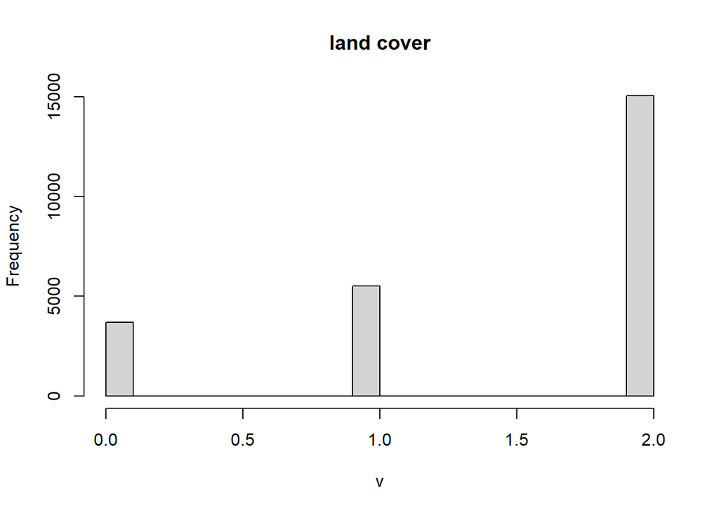

```r
hist(cdl)   #histogram of values
```

### Simple Maps from Raster Data

#### plotting with `base R`

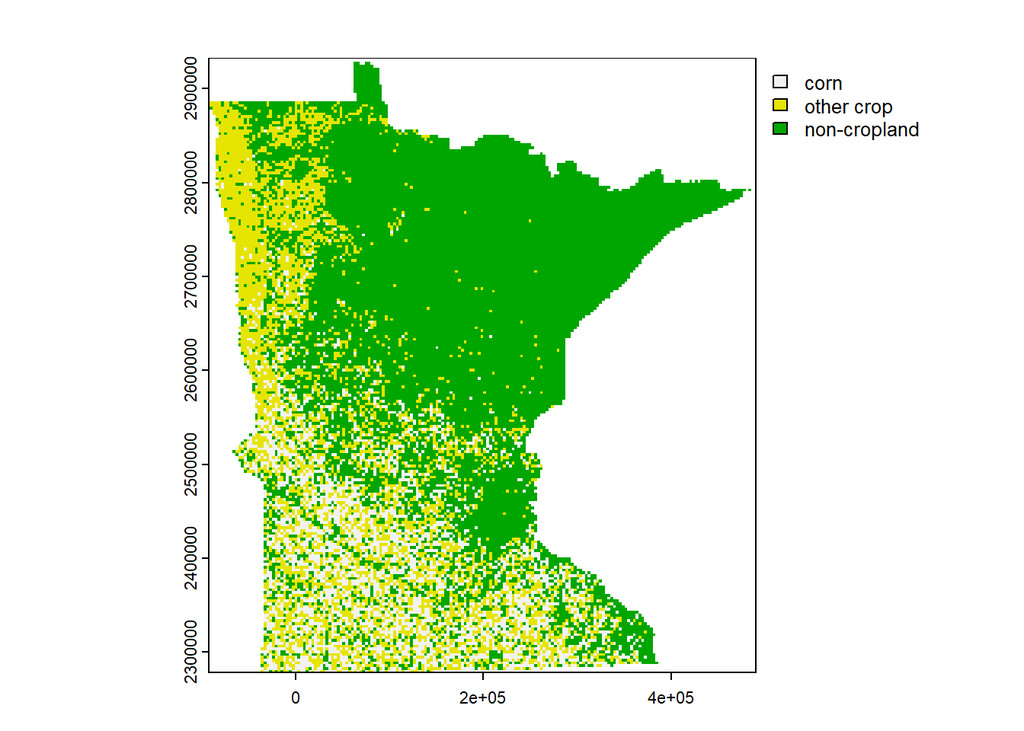

```r
plot(cdl)
```

#### plotting with `tmap`

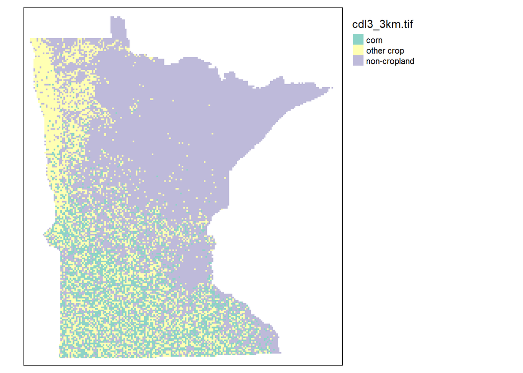

```r
tm_shape(cdl) +
  tm_raster() +
  tm_layout(legend.outside = TRUE)
```

### Export Raster Data

`writeRaster(obj, "./path/.../filename.tif", overwrite=TRUE)`

I recommend you write out your raster objects as GeoTiff files

### **Exercise 3: Explore Malawi LSMS Wave 5 (Raster) Data**

> *Data Source:*  
> The data were aggregated from SRTM 90 m resolution data between -60 and 60 latitude.

The data will be downloaded directly using the `geodata::elevation_30s()` function in R

1. Using the command `mwi_dem <- elevation_30s(country='MWI', mask=TRUE, path = "../data/MWI")`, download the digital elevation model (dem) data for Malawi.

   ```r
   # Use this code block to work through the exercise
   # Answers are available in separate .RMD file for Exercise 3
   ```

2. Set coordinate reference system using the command `crs(mwi_dem) <- "epsg:4326"`

   ```r
   # Use this code block to work through the exercise
   # Answers are available in separate .RMD file for Exercise 3
   ```

3. Explore the characteristics of your raster.
   1. How many rows and columns does it have?
   2. What is the resolution?
   3. What is the coordinate reference system?
   4. What is the distribution of values?

   ```r
   # Use this code block to work through the exercise
   # Answers are available in separate .RMD file for Exercise 3
   ```

4. Create some maps
   1. Plot a map of elevation in base R.
   2. Plot a map of elevation in tmap.

   ```r
   # Use this code block to work through the exercise
   # Answers are available in separate .RMD file for Exercise 3
   ```

## **Layering Features**

Now that you know how to import and map vector and raster data you can start layering muliple objects on top of one another in your maps.

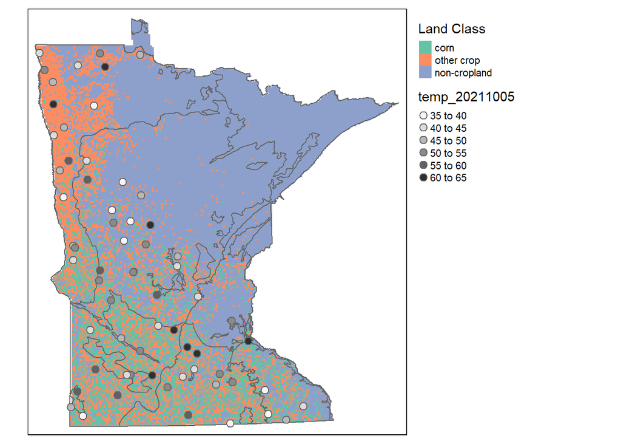

```r
tm_shape(cdl) + tm_raster(title = "Land Class", palette = "Set2") +
  tm_shape(gw_prov) + tm_borders() +
  tm_shape(soil_samp) + tm_bubbles("temp_20211005", size = 0.2, palette = "Greys") +
  tm_layout(legend.outside = TRUE)
```

### Picking Colors

I recommend using the Color Brewer website to pick color palettes for your maps: https://colorbrewer2.org/

### Export tmap Images

`tmap_save(obj, "./path/.../filename.png", height = 4, width = 6, unit = "in")`

### **Exercise 4: Maps with Multiple Features**

1. Create a `tmap` object with three features
   1. Malawi DEM (raster)
   2. Malawi district boundaries borders (polygon)
   3. Malawi LSMS surveyed enumeration areas (point)

   ```r
   # Use this code block to work through the exercise
   # Answers are available in separate .RMD file for Exercise 4
   ```